# Technical Analysis: DATS 6101 Final Project

Brandon Chin, Paul Kelly, Ksenia Shadrina, Luke Wu

4/27/22

# I. Introduction

There is considerable evidence indicating historical discriminatory lending practices throughout the United States. (Steil et al.: 2018) In our research, we explore lending practices in California in 2019. We focus on California in part due to a very large number of observations on California in the Federal Financial Institutions Examination Council’s (FFIEC) Home Mortgage Disclosure Act (HMDA) dataset. We also examine the housing market in California because the state presents an interesting case study due to its large and increasingly diverse population (Public Policy Institute: 2022) and dynamic economy. By analyzing the data from 2019, we get the most recent glimpse at lending practices before the onset of the economic crisis induced by the COVID-19 pandemic. While the dataset is very detailed and presents an opportunity for rigorous research, we must narrow the scope of the analysis given the time constraints.

In the course of the midterm project research, we discovered that answering our original SMART question would require, at the very least, building a logistic regression model. In addition, we discovered that we had an unbalanced dataset which behooved us to increase our sample size significantly: from 5,441 to 50,000 observations on California.

Based on our initial findings, we proceeded to testing the relationship between rate of loan denials and income of applicant, loan amount, interest rate, property value, gender of applicant, race of applicant, age of applicant, ethnicity of applicant. These variables were chosen in the first part of the research based on economic theory, completeness of the data, and brief literature review described in the next section. Thus, our SMART question remained largely unchanged:

“Which factors drove denials for mortgages in California in 2019?”

Similarly to the midterm project, we conducted various data cleaning and exploration exercises. After constructing a number of logistic regression models without finding a good fit, we used the classification tree technique.

# II. Brief Literature Review

A number of recent studies have examined factors associated with either mortgage denial rates or cost of loans. The literature reviewed within the scope of our research suggested evidence of disparities in mortgage lending practices across race, ethnicity, age, and gender.

Bayer, Ferreira, and Ross (2014) examine lending practices in seven large metropolitan areas, including Los-Angeles CA CMSA and San Francisco, CA between 2004 and 2008 using HMDA data - the same dataset that we employ in our study. The authors find that the incidence of high cost loans is higher for African American and Hispanic borrowers even after controlling for key mortgage risk factors such as borrower credit score.

In examining differences in the share of applications denied by lenders, similar to our focus, Park (2022) addresses the possible omitted variable bias driven by previously missing data in earlier studies by estimating expected risk with a detailed set of underwriting characteristics available in newly available HMDA and Federal Housing Administration (FHA) data between 2010 and 2019. The author finds evidence of disparities in denials rates across race, ethnicity, and gender that “cannot be fully explained by differences in default risk.”

A recent study by the Urban Institute (2021) examined the relationship between mortgage denial rates and age, also using the HMDA data. The authors find that older applicants are indeed more likely to be denied than younger applicants. The authors also find that household financial characteristics are likely contributing to denial rates higher for older homeowners. Using data from the Federal reserve, the authors note that the share of individuals ages older and 65 that have debt is substantially higher than 20 years ago.

# III. Data Cleaning and EDA

All of the data cleaning procedures remained the same as in the midterm; therefore, our starting point here is 24,018 observations. Specifically, we filtered on the action_taken of denial and approval, removed all the business properties, removed outliers, and removed the missing values. The resulting dataset “loans.csv” is our starting point.

```r
loans <- data.frame(read.csv("loans.csv"))
str(loans) #24018 obs. of  9 variables # dropped applicant sex because it's essentially the same as derived sex
```

```r
loans$derived_ethnicity = factor(loans$derived_ethnicity)
loans$derived_race = factor(loans$derived_race)
loans$derived_sex = factor(loans$derived_sex)
loans$loan_amount = as.numeric(loans$loan_amount)
loans$interest_rate = as.numeric(loans$interest_rate)
loans$property_value = as.numeric(loans$property_value)
loans$income = as.numeric(loans$income)
loans$applicant_age = factor(loans$applicant_age)
str(loans)
```

We ran the summary statistics on the four numerical variables, noting different scales. (Table 1.) We also note that the data are not normally distributed.

```r
options(scipen=9, digits = 3)
Numerical_var <- subset(loans,select=c(loan_amount, income, property_value, interest_rate))
library(kableExtra)
summary_t<-kbl(summary(Numerical_var))%>%
  kable_styling()
summary_t
```

|  | loan_amount | income | property_value | interest_rate |
| --- | --- | --- | --- | --- |
|  | Min. : 5000 | Min. :-19 | Min. : 15000 | Min. :2.12 |
|  | 1st Qu.:155000 | 1st Qu.: 64 | 1st Qu.: 375000 | 1st Qu.:3.62 |
|  | Median :315000 | Median : 98 | Median : 505000 | Median :4.13 |
|  | Mean :320331 | Mean :104 | Mean : 531758 | Mean :4.15 |
|  | 3rd Qu.:455000 | 3rd Qu.:138 | 3rd Qu.: 655000 | 3rd Qu.:4.46 |
|  | Max. :965000 | Max. :263 | Max. :1195000 | Max. :6.12 |

We then do a visual inspection of the new dataset, starting with categorical values.

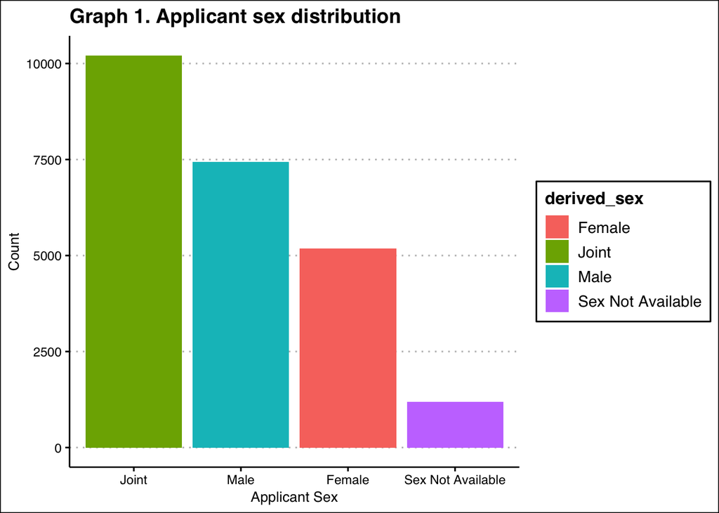

```r
library(ggthemes)
library(forcats)
library(ggplot2)
mfrow=c(2, 3)
ggplot(loans, aes(x  = fct_infreq(derived_sex), fill=derived_sex)) +
    geom_bar()+
  labs(title="Graph 1. Applicant sex distribution", x="Applicant Sex", y="Count")+theme_clean()
```

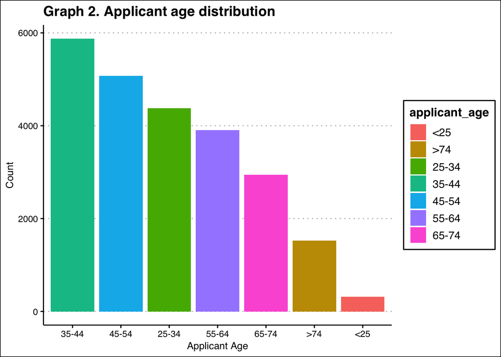

```r
ggplot(loans, aes(x = fct_infreq(applicant_age),fill=applicant_age)) +
    geom_bar()+
  labs(title="Graph 2. Applicant age distribution", x="Applicant Age", y="Count")+theme_clean()
```

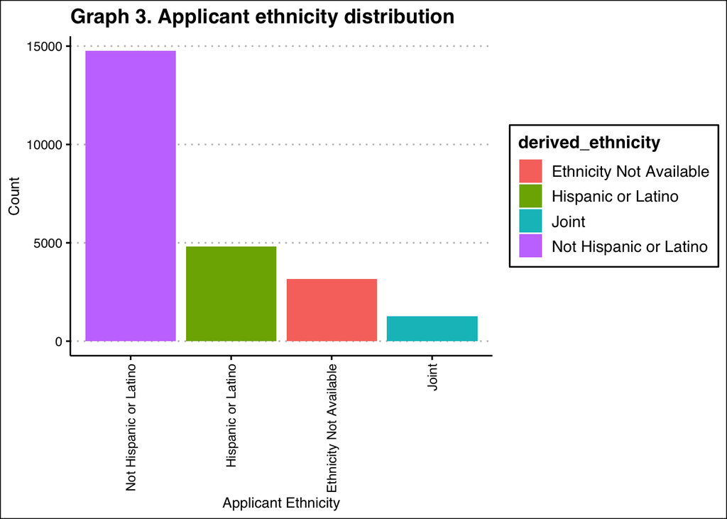

```r
ggplot(loans, aes(x = fct_infreq(derived_ethnicity), fill=derived_ethnicity))+
geom_bar()+theme_clean()+
  labs(title="Graph 3. Applicant ethnicity distribution", x="Applicant Ethnicity", y="Count")+theme(axis.text.x = element_text(angle = 90, vjust = 0.5, hjust=1))
```

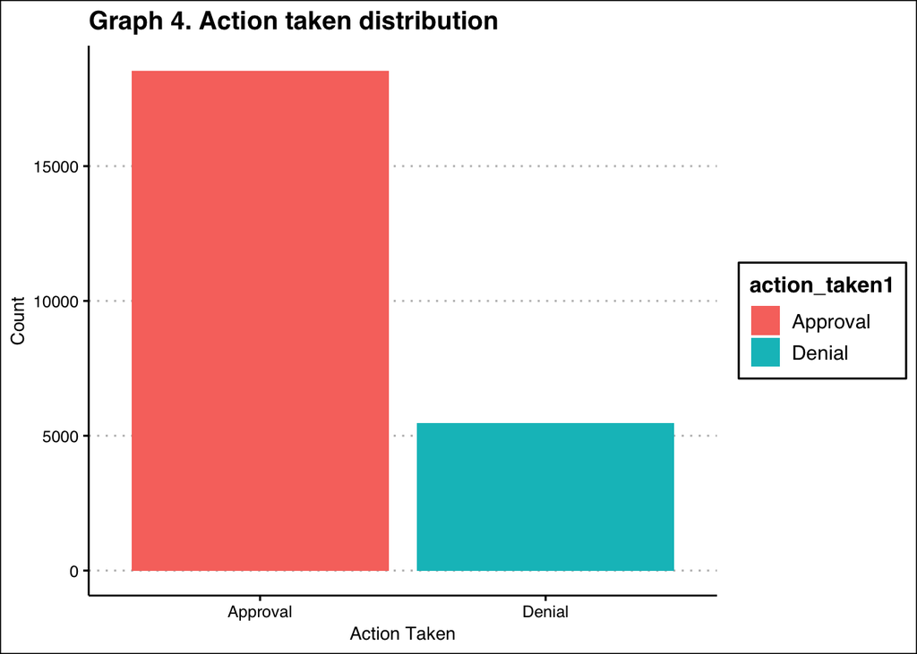

```r
loans$action_taken1<-dplyr::recode(loans$action_taken, "3"="Denial", "1"="Approval") #recode for the purposes of visuals

ggplot(loans, aes(x = fct_infreq(as.factor(action_taken1)), fill=action_taken1)) +
    geom_bar()+
  labs(title="Graph 4. Action taken distribution", x="Action Taken", y="Count")+theme_clean()
```

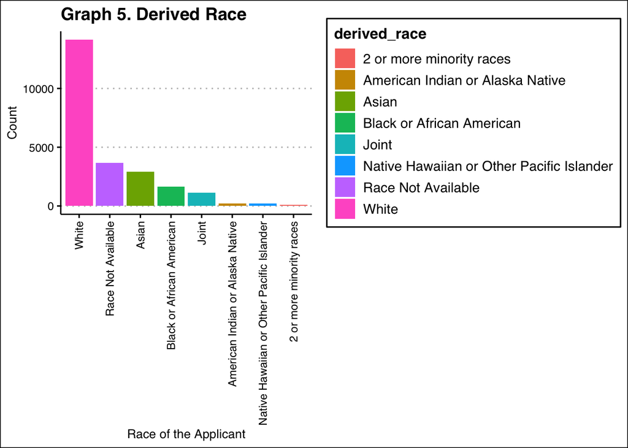

```r
ggplot(loans, aes(x = fct_infreq(derived_race), fill=derived_race)) +
   geom_bar(stat = 'count') + theme_clean()+
  labs(title="Graph 5. Derived Race", x="Race of the Applicant", y= "Count")+theme(axis.text.x = element_text(angle = 90, vjust = 0.5, hjust=1))
```

There are three noteworthy features in the categorical graphs which communicate the same story about the distribution of variables as in our midterm project.

First, we note that ethnicity and race variables are overly represented by “Not Hispanic or Latino” and “white” are overrepresented. Secondly, there is an obvious overlap between these two variables with the skew in these two respective categories, and in future research, these two variables should either be combined or used in separate models. Third, the action_taken graph is heavily skewed on approvals, and thus, to answer our SMART question, we will have to balance the dataset.

Next, we proceed to examining the numerical variable histograms.

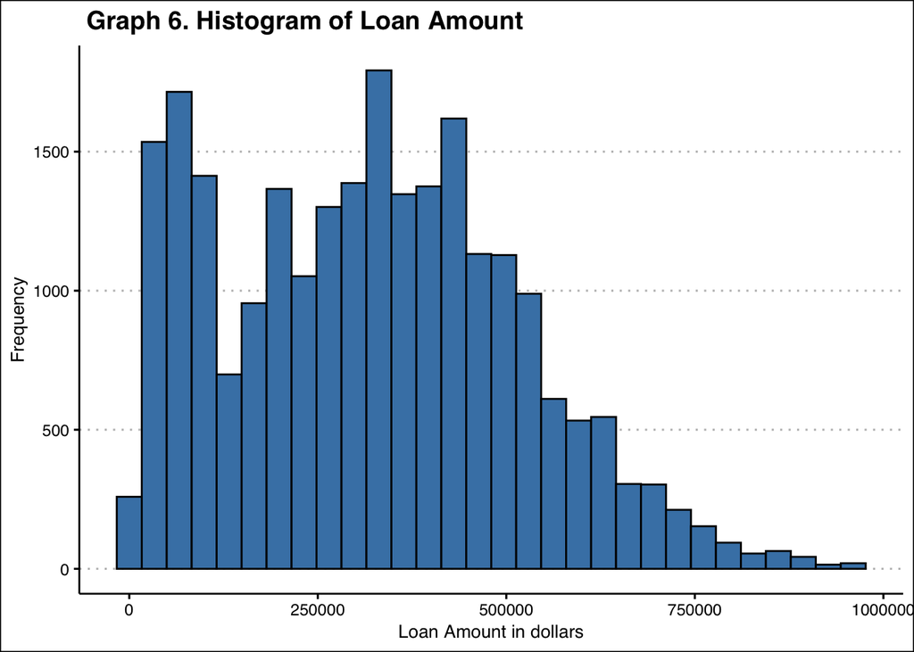

```r
mfrow=c(2, 3)
ggplot(loans,aes(x=loan_amount))+
  geom_histogram(color="black", fill="steelblue")+
  labs(title=" Graph 6. Histogram of Loan Amount", x="Loan Amount in dollars", y="Frequency")+theme_clean()
```

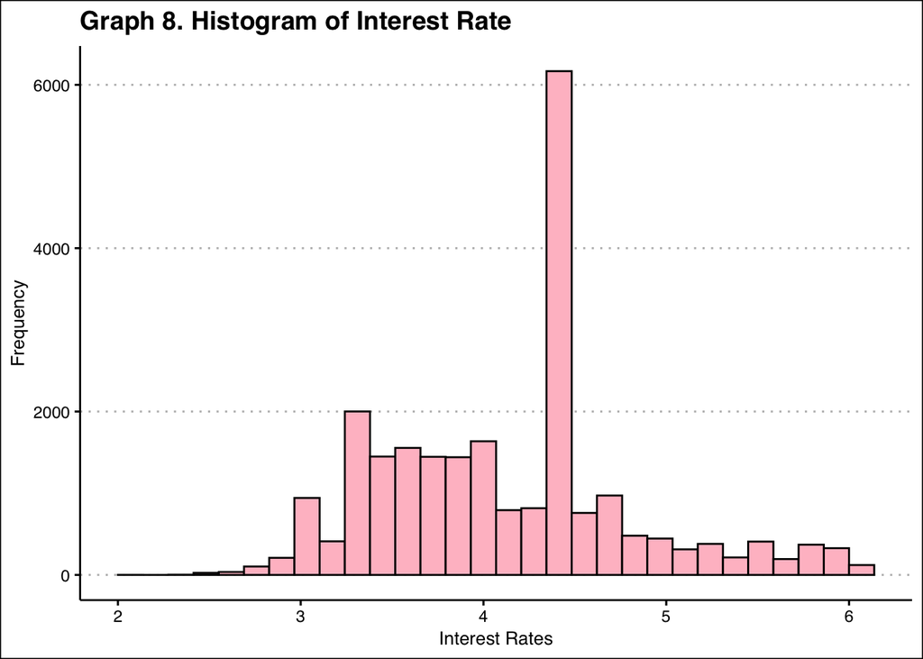

```r
ggplot(loans,aes(x=interest_rate))+
  geom_histogram(color="black", fill="pink")+
  labs(title="Graph 8. Histogram of Interest Rate", x="Interest Rates", y="Frequency")+theme_clean()
```

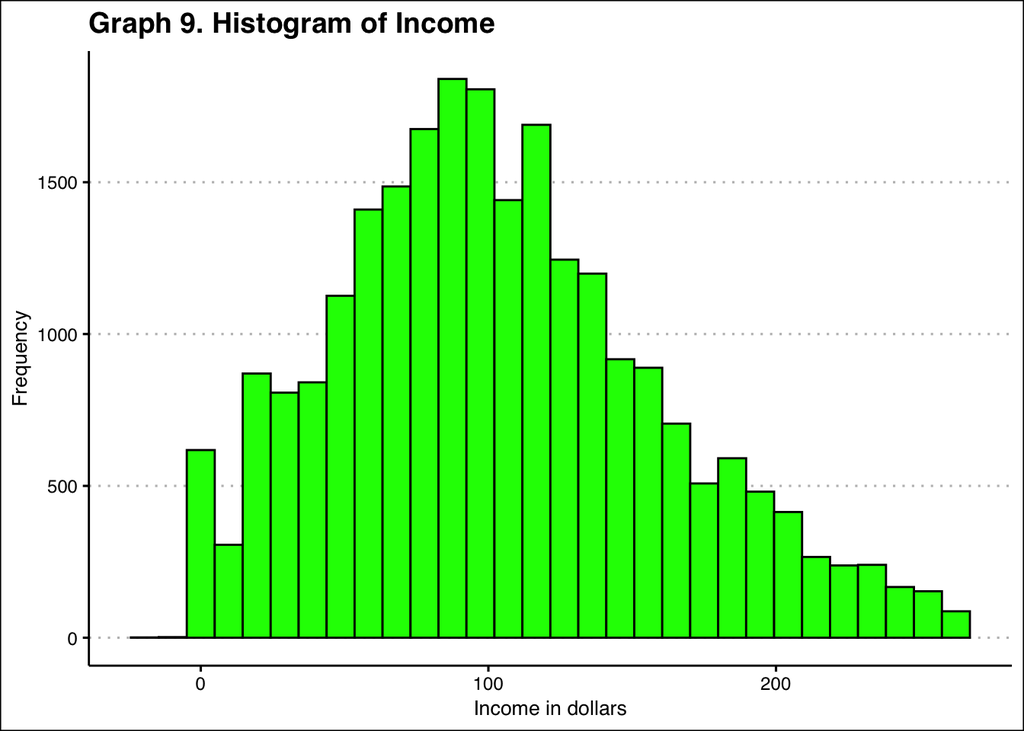

```r
ggplot(loans,aes(x=income))+
  geom_histogram(color="black", fill="green")+
  labs(title="Graph 9. Histogram of Income", x="Income in dollars", y="Frequency")+theme_clean()
```

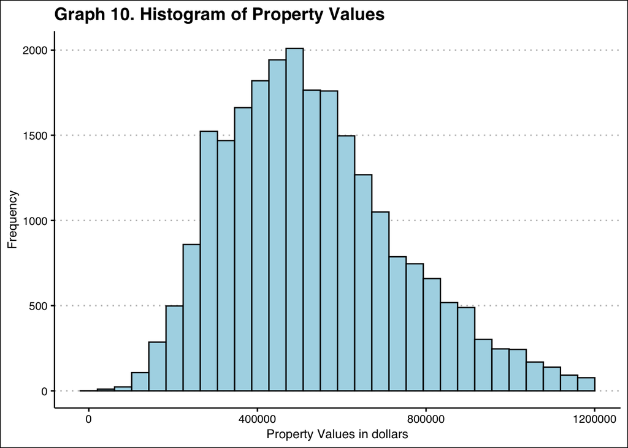

```r
ggplot(loans,aes(x=property_value))+
  geom_histogram(color="black", fill="lightblue")+
  labs(title="Graph 10. Histogram of Property Values", x="Property Values in dollars", y="Frequency")+theme_clean()
```

Only income and property values appear to approach normal distribution. We proceed without taking any additional outliers out because balancing of the data will require us to remove additonal data.

We decided to run to chi-square tests on the unbalanced data first, and contrary to the results we got in the midterm project, all tests ran well and rejected the null hypothesis of independence between categorical variables describing attributes of applicants and the approval or denial status for a loan.

```r
library(kableExtra)
contable1= table(loans$derived_race, loans$action_taken1)
xkabledply(contable1, title="Contingency table for Loan Approval and Race")
```

Contingency table for Loan Approval and Race

|  | Approval | Denial |
| --- | --- | --- |
| 2 or more minority races | 56 | 51 |
| American Indian or Alaska Native | 141 | 82 |
| Asian | 2129 | 769 |
| Black or African American | 1000 | 638 |
| Joint | 855 | 257 |
| Native Hawaiian or Other Pacific Islander | 115 | 80 |
| Race Not Available | 2763 | 923 |
| White | 11483 | 2676 |

```r
chitest1 = chisq.test(contable1)
chitest1
```

```
##
##  Pearson's Chi-squared test
##
## data:  contable1
## X-squared = 498, df = 7, p-value <2e-16
```

```r
contable2= table(loans$derived_ethnicity, loans$action_taken1)
xkabledply(contable2, title="Contingency table for Loan Approval and Ethnicity")
```

Contingency table for Loan Approval and Ethnicity

|  | Approval | Denial |
| --- | --- | --- |
| Ethnicity Not Available | 2417 | 741 |
| Hispanic or Latino | 3568 | 1248 |
| Joint | 1014 | 266 |
| Not Hispanic or Latino | 11543 | 3221 |

```r
chitest2 = chisq.test(contable2)
chitest2
```

```
##
##  Pearson's Chi-squared test
##
## data:  contable2
## X-squared = 38, df = 3, p-value = 0.00000002
```

```r
contable3= table(loans$derived_sex, loans$action_taken1)
xkabledply(contable3, title="Contingency table for Loan Approval and Gender")
```

Contingency table for Loan Approval and Gender

|  | Approval | Denial |
| --- | --- | --- |
| Female | 3914 | 1266 |
| Joint | 8337 | 1874 |
| Male | 5427 | 2014 |
| Sex Not Available | 864 | 322 |

```r
chitest3 = chisq.test(contable3)
chitest3
```

```
##
##  Pearson's Chi-squared test
##
## data:  contable3
## X-squared = 212, df = 3, p-value <2e-16
```

```r
contable4= table(loans$applicant_age, loans$action_taken1)
xkabledply(contable4, title="Contingency table for Loan Approval and Age")
```

Contingency table for Loan Approval and Age

|  | Approval | Denial |
| --- | --- | --- |
| <25 | 256 | 57 |
| >74 | 1217 | 309 |
| 25-34 | 3572 | 805 |
| 35-44 | 4546 | 1331 |
| 45-54 | 3788 | 1288 |
| 55-64 | 2911 | 992 |
| 65-74 | 2252 | 694 |

```r
chitest4 = chisq.test(contable4)
chitest4
```

```
##
##  Pearson's Chi-squared test
##
## data:  contable4
## X-squared = 93, df = 6, p-value <2e-16
```

Despite the chi-square tests running well and confirming that denial or approvals are not independent of personal attributes of the applicants: race, ethnicity, age, and sex, we know that our dataset is unbalanced between the number of approvals and denials based on EDA. Before constructing the logistical model, we first balance the data.

# IV. Balancing dataset

We knew from data exploration that our dataset was unbalanced. Our team decided to use the downsampling technique to balance our dataset. The dataset is currently over representing approvals rather than denials therefore we set the amount of observations that are flagged as Approved to the same amount that the dataset currently has for denial.

```r
hmda <- data.frame(loans)
hmda$approval<- ifelse(hmda$action_taken=="1", "Approved","Denied")
hmda$approval<- factor(hmda$approval)
str(hmda)
table(hmda$approval)
```

The number of approvals is over three times higher than denials as shown in the table below.

```r
with(hmda,
     {
       print(table(derived_race))
       print(table(approval))
     }
)
```

```
## derived_race
##                  2 or more minority races
##                                       107
##          American Indian or Alaska Native
##                                       223
##                                     Asian
##                                      2898
##                 Black or African American
##                                      1638
##                                     Joint
##                                      1112
## Native Hawaiian or Other Pacific Islander
##                                       195
##                        Race Not Available
##                                      3686
##                                     White
##                                     14159
## approval
## Approved   Denied
##    18542     5476
```

To balance the dataset, the downsampling technique is used. Balancing the dataset leaves us with 10,952 observations.

```r
Approved<- which(hmda$action_taken=="1")
Denied<- which(hmda$action_taken=="3")

length(Approved)
```

```
## [1] 18542
```

```r
length(Denied)
```

```
## [1] 5476
```

```r
#The technique
approved_downsample<-sample(Approved,length(Denied))
hmda_down<- hmda[c(approved_downsample, Denied),]
str(hmda_down)
```

```
## 'data.frame':    10952 obs. of  11 variables:
##  $ derived_ethnicity: Factor w/ 4 levels "Ethnicity Not Available",..: 4 1 4 2 4 4 4 4 1 3 ...
##  $ derived_race     : Factor w/ 8 levels "2 or more minority races",..: 8 7 8 8 8 8 8 8 7 8 ...
##  $ derived_sex      : Factor w/ 4 levels "Female","Joint",..: 1 2 3 1 3 2 3 1 3 2 ...
##  $ action_taken     : int  1 1 1 1 1 1 1 1 1 1 ...
##  $ loan_amount      : num  315000 525000 305000 55000 405000 465000 545000 185000 545000 325000 ...
##  $ interest_rate    : num  4.5 3.62 3.99 2.99 3.62 ...
##  $ property_value   : num  375000 655000 345000 605000 405000 685000 685000 205000 665000 335000 ...
##  $ income           : num  69 140 74 115 93 98 115 36 95 87 ...
##  $ applicant_age    : Factor w/ 7 levels "<25",">74","25-34",..: 6 6 3 6 3 6 3 4 4 3 ...
##  $ action_taken1    : chr  "Approval" "Approval" "Approval" "Approval" ...
##  $ approval         : Factor w/ 2 levels "Approved","Denied": 1 1 1 1 1 1 1 1 1 1 ...
```

```r
#10952 obs. of  11 variables
```

```r
hmda_down$action_taken1<-dplyr::recode(hmda_down$action_taken, "1"="Denial", "0"="Approval") #recode for the purposes of visuals; only used for chi-square tests and ggplot
contable1= table(hmda_down$derived_race, hmda_down$action_taken1)
xkabledply(contable1, title="Balanced Data: Contingency table for Loan Approval and Race")
```

Balanced Data: Contingency table for Loan Approval and Race

|  | Denial |
| --- | --- |
| 2 or more minority races | 16 |
| American Indian or Alaska Native | 43 |
| Asian | 630 |
| Black or African American | 295 |
| Joint | 237 |
| Native Hawaiian or Other Pacific Islander | 36 |
| Race Not Available | 791 |
| White | 3428 |

```r
chitest1 = chisq.test(contable1)
chitest1
```

```
##
##  Chi-squared test for given probabilities
##
## data:  contable1
## X-squared = 13400, df = 7, p-value <2e-16
```

```r
contable2= table(hmda_down$derived_ethnicity, hmda_down$action_taken1)
xkabledply(contable2, title="Balanced Data: Contingency table for Loan Approval and Ethnicity")
```

Balanced Data: Contingency table for Loan Approval and Ethnicity

|  | Denial |
| --- | --- |
| Ethnicity Not Available | 709 |
| Hispanic or Latino | 1031 |
| Joint | 305 |
| Not Hispanic or Latino | 3431 |

```r
chitest2 = chisq.test(contable2)
chitest2
```

```
##
##  Chi-squared test for given probabilities
##
## data:  contable2
## X-squared = 4334, df = 3, p-value <2e-16
```

```r
contable3= table(hmda_down$derived_sex, hmda_down$action_taken1)
xkabledply(contable3, title="Balanced Data: Contingency table for Loan Approval and Gender")
```

Balanced Data: Contingency table for Loan Approval and Gender

|  | Denial |
| --- | --- |
| Female | 1147 |
| Joint | 2457 |
| Male | 1636 |
| Sex Not Available | 236 |

```r
chitest3 = chisq.test(contable3)
chitest3
```

```
##
##  Chi-squared test for given probabilities
##
## data:  contable3
## X-squared = 1890, df = 3, p-value <2e-16
```

```r
contable4= table(hmda_down$applicant_age, hmda_down$action_taken1)
xkabledply(contable4, title="Balanced Data: Contingency table for Loan Approval and Age")
```

Balanced Data: Contingency table for Loan Approval and Age

|  | Denial |
| --- | --- |
| <25 | 78 |
| >74 | 366 |
| 25-34 | 1094 |
| 35-44 | 1314 |
| 45-54 | 1147 |
| 55-64 | 841 |
| 65-74 | 636 |

```r
chitest4 = chisq.test(contable4)
chitest4
```

```
##
##  Chi-squared test for given probabilities
##
## data:  contable4
## X-squared = 1543, df = 6, p-value <2e-16
```

As a first step to building the logit model, we recode it to 1 as denial and 0 as approval because of how our SMART question is formulated.

```r
hmda_down$action_taken<-dplyr::recode(hmda_down$action_taken, "3"="1", "1"="0")
unique(hmda_down$action_taken)
hmda_down$action_taken<-factor(hmda_down$action_taken)

myvars <- names(hmda_down) %in% c("approval", "action_taken1") # dropping approval and action_1 since we don't need these variables anymore
newdata <- hmda_down[!myvars]
hmda_down<-newdata
str(hmda_down)
```